# Lab3 Notebook

```r
library(ggplot2)
library(fit.models)
library(tidyr)
library('reshape2')
library(robust)
library("MASS")
library("jpeg")
library(tclust, quietly = TRUE)
library(EMCluster, quietly = TRUE)
```

```r
#Exercice 1 Summary statistics
set.seed(123)
datas <- rt(15, 1)
mean(datas) #23.03012
```

```
[1] 23.03012
```

```r
#The mean is not a good summary because it should be near to 0.
#It is due to outliers points and in particular a 315
summary(datas)
```

```
    Min.  1st Qu.   Median     Mean  3rd Qu.     Max.
 -5.7826  -1.4157  -0.2721  23.0301   0.9178 315.2623
```

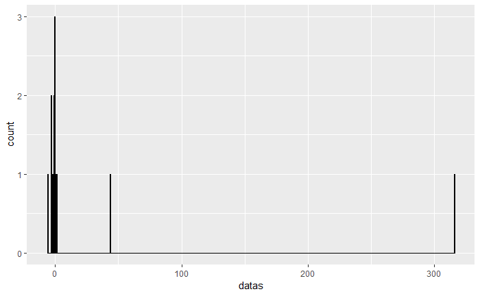

```r
df = data.frame(datas)
ggplot(df, aes(x=datas)) +
  geom_histogram(binwidth=.5, colour="black", fill="white")
```

```r
#We can propose the median which is less influenced to outliers
median(datas)
```

```
[1] -0.2721196
```

```r
#The trimmed mean
mean(datas, trim = 0.2)
```

```
[1] -0.3335567
```

```r
#Or the standart Deviation
sd(datas)
```

```
[1] 81.66803
```

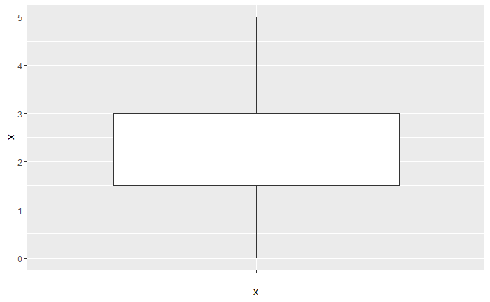

```r
# Exercice2 ----------------------------------------------------------------------
toyData = data.frame('x' = c(1,2,3,2,0,3,4,1,2,3,0,1,2,2,3,0,3,3,4,3,3,4,5))
ggplot(toyData, aes(x = '', y=x)) +
  geom_boxplot()
```

Here we have a dataset with values between 0 and 4 and one data equal to 5. 5 is an outlier but it is not shown by the boxplot.

```r
# Exercice3 ----------------------------------------------------------------------
#Briefly describe the dataset.p
#The dataset contains datas about 87 characters of Star Wars.
#It is physical datas like name, height or skin color
#but we have the list of movies were they appear, their vehicls and starships too
dfStarWars <- dplyr::starwars
#Consider the variables height and mass, plot univariate charts to study the range and other summary statistics
summary(dfStarWars['height'])
```

```
     height
 Min.   : 66.0
 1st Qu.:167.0
 Median :180.0
 Mean   :174.4
 3rd Qu.:191.0
 Max.   :264.0
 NA's   :6
```

```r
summary(dfStarWars['mass'])
```

```
      mass
 Min.   :  15.00
 1st Qu.:  55.60
 Median :  79.00
 Mean   :  97.31
 3rd Qu.:  84.50
 Max.   :1358.00
 NA's   :28
```

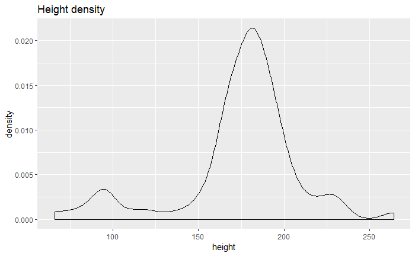

```r
ggplot(dfStarWars, aes(x = height)) + geom_density() + ggtitle("Height density")
```

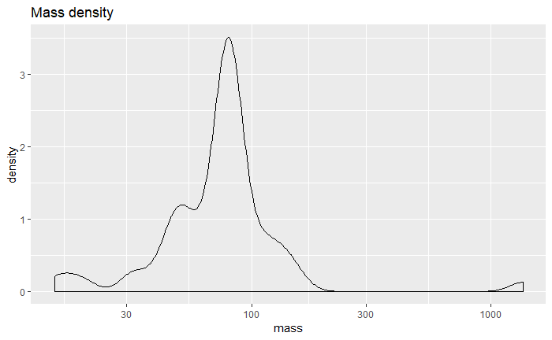

```r
ggplot(dfStarWars, aes(x = mass)) + geom_density() + ggtitle("Mass density") + scale_x_log10()
```

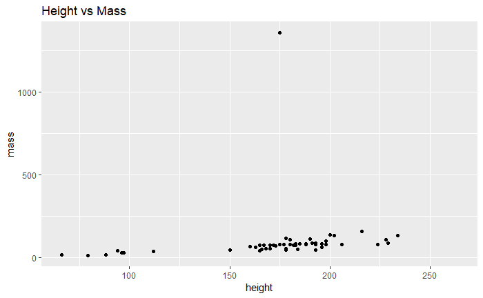

```r
#Plot mass vs height and describe it
ggplot(dfStarWars, aes(x = height, y = mass)) + geom_point() + ggtitle("Height vs Mass")
```

```r
#The mass of a character seems connected to its height. For characters between 150 and 250 cm we could do
#a linear regression because it seems to be a straight.
#We have an extreme outlier (1000kg and 175cm) which correspond to Jabba
#Fit two different regression models. Plot and discuss the results. Useful: lmrob or MASS::rlm
sub <- subset(dfStarWars, select=c(mass,height,name))
sub <- drop_na(sub)
lmRegression <- lm(sub)
rlmRegression <- rlm(x = as.numeric(unlist(sub['mass'])) ,y = as.numeric(unlist(sub['height'])))
```

```r
print(lmRegression)
```

```
Call:
lm(formula = sub)

Coefficients:
              (Intercept)                     height             nameAdi Gallia
                -337.0000                     2.3333                   -42.3333
     nameAnakin Skywalker            nameAyla Secura          nameBarriss Offee
                 -17.6667                   -23.3333                    -0.3333
       nameBen Quadinaros     nameBeru Whitesun lars      nameBiggs Darklighter
                  21.6667                    27.0000                    -6.0000
            nameBoba Fett                  nameBossk                  nameC-3PO
                 -11.8000                     6.6667                    22.3333
            nameChewbacca             nameDarth Maul            nameDarth Vader
                 -83.0000                     8.6667                     1.6667
      nameDexter Jettster                  nameDooku               nameDud Bolt
                 -23.0000                   -33.3333                   162.6667
               nameGreedo           nameGregar Typho               nameGrievous
                   7.3333                    -9.6667                    -8.0000
             nameHan Solo                  nameIG-88  nameJabba Desilijic Tiure
                  -3.0000                    10.3333                  1286.6667
           nameJango Fett          nameJar Jar Binks       nameJek Tono Porkins
                 -11.0000                   -54.3333                    27.0000
         nameKi-Adi-Mundi              nameKit Fisto                nameLama Su
                 -43.0000                   -33.3333                  -109.3333
     nameLando Calrissian            nameLeia Organa                  nameLobot
                   3.0000                    36.0000                     7.6667
       nameLuke Skywalker        nameLuminara Unduli             nameMace Windu
                  12.6667                    -3.4667                   -17.6667
            nameNien Nunb            nameNute Gunray         nameObi-Wan Kenobi
                  31.6667                   -18.6667                   -10.6667
            nameOwen Lars          namePadmé Amidala              namePalpatine
                  41.6667                    -3.0000                    15.3333
             namePlo Koon      namePoggle the Lesser           nameQui-Gon Jinn
                 -21.6667                   -10.0000                   -24.3333
                nameR2-D2                  nameR5-D4          nameRatts Tyerell
                 145.0000                   142.6667                   167.6667
      nameRaymus Antilles           nameRoos Tarpals                nameSebulba
                 -22.6667                  -103.6667                   115.6667
             nameShaak Ti              nameSly Moore                nameTarfful
                 -21.3333                   -30.3333                   -73.0000
           nameTion Medon             nameWat Tambor         nameWedge Antilles
                 -63.6667                   -65.3333                    17.3333
nameWicket Systri Warrick                   nameYoda             nameZam Wesell
                 151.6667                   200.0000                         NA
```

```r
summary(rlmRegression)
```

```
Call: rlm(x = as.numeric(unlist(sub["mass"])), y = as.numeric(unlist(sub["height"])))
Residuals:
     Min       1Q   Median       3Q      Max
-2337.17    27.28    35.01    51.13   104.20

Coefficients:
                                Value   Std. Error t value
as.numeric(unlist(sub["mass"]))  1.8499  0.0366    50.5432

Residual standard error: 56.05 on 58 degrees of freedom
```

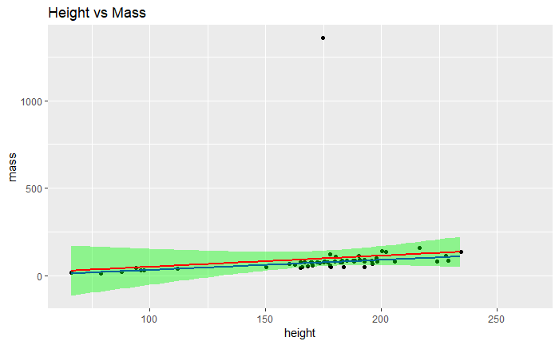

```r
heightAndMassGraph <- ggplot(dfStarWars, aes(x = height, y = mass))
heightAndMassGraph <- heightAndMassGraph + geom_point(position = "jitter")
heightAndMassGraph <- heightAndMassGraph + ggtitle("Height vs Mass")+geom_smooth(method = rlm, color = 'blue')
heightAndMassGraph + geom_smooth(method = lm, color = 'red', fill = 'green')
```

We see that the robust regression in blue is further the outlier point. So this model is less affected by as expected outliers The confidence interval in green is for the lm model.

```r
weights <- data.frame(rlmRegression['w'])
print(weights)
```

| w |
| --- |
| 1.00000000 |
| 1.00000000 |
| 1.00000000 |
| 1.00000000 |
| 1.00000000 |
| 1.00000000 |
| 1.00000000 |
| 1.00000000 |
| 1.00000000 |
| 1.00000000 |

[output cut: 49 more lines]

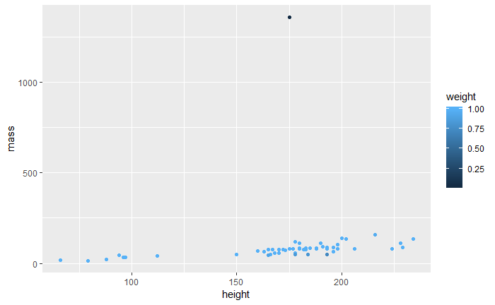

```r
sub['weight'] = weights
WeightMGraph  <- ggplot(sub, aes(x = height, y = mass, color = weight))
WeightMGraph + geom_point()
```

We can see that it is the outlier point which have the lowest weight value.

```r
print(sub[which.min(sub$weight),])
```

| mass | height | name | weight |
| --- | --- | --- | --- |
| 1358 | 175 | Jabba Desilijic Tiure | 0.03225843 |

The outlier point is Jabba Desilijic Tiure as expected

[figure not shown]

```r
JabbaImage <- readJPEG("personnage-jabba-the-hutt.jpg",native=TRUE)
plot(0:1,0:1,type="n",ann=FALSE,axes=FALSE)
rasterImage(JabbaImage,0,0,1,1)
```

```r
sub <- sub[-which.min(sub$weight),] # On supprime la ligne de Jabba
```

We redo the same thing without Jabba

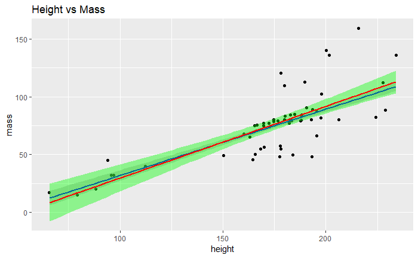

```r
sub <- subset(sub, select=c(mass,height,name))
lmRegression <- lm(sub)
rlmRegression <- rlm(x = as.numeric(unlist(sub['mass'])) ,y = as.numeric(unlist(sub['height'])))
heightAndMassGraph <- ggplot(sub, aes(x = height, y = mass))
heightAndMassGraph <- heightAndMassGraph + geom_point(position = "jitter")
heightAndMassGraph <- heightAndMassGraph + ggtitle("Height vs Mass")+geom_smooth(method = rlm, color = 'blue')
heightAndMassGraph + geom_smooth(method = lm, color = 'red', fill = 'green')
```

```r
weights <- data.frame(rlmRegression['w'])
print(weights)
```

| w |
| --- |
| 1.0000000 |
| 1.0000000 |
| 1.0000000 |
| 0.3918975 |
| 0.9747237 |
| 0.4429842 |
| 1.0000000 |
| 1.0000000 |
| 1.0000000 |
| 1.0000000 |

[output cut: 48 more lines]

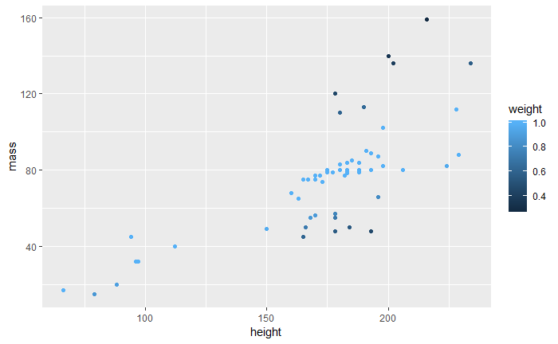

```r
sub['weight'] = weights
WeightMGraph  <- ggplot(sub, aes(x = height, y = mass, color = weight))
WeightMGraph + geom_point()
```

```r
print(sub[which.min(sub$weight),])
```

| mass | height | name | weight |
| --- | --- | --- | --- |
| 159 | 216 | Grievous | 0.2864406 |

The new character with the lowest weight is the general Grievous

```r
newdata=data.frame("name"="Luke Skywalker", "mass", "height" = 170)
result=predict(lmRegression,newdata)
```

[output not shown]

```r
print(result)
```

```
       1
72.33333
```

According to our model a 1m70 character will do 72.3 kg

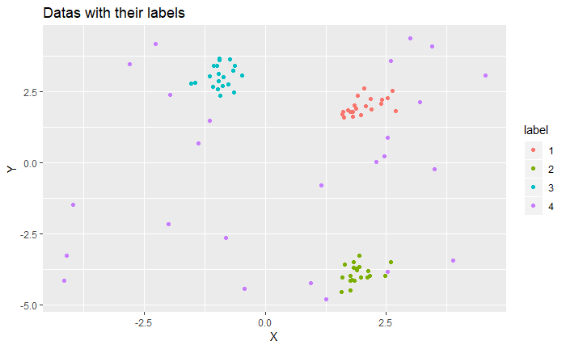

```r
#Exercice 4 Robust EM
x1 = mvrnorm(n = 20, 2, 0.1, tol = 1e-06, empirical = FALSE)
y1 = mvrnorm(n = 20, 2, 0.1, tol = 1e-06, empirical = FALSE)
x2 = mvrnorm(n = 20, 2, 0.1, tol = 1e-06, empirical = FALSE)
y2 = mvrnorm(n = 20, -4, 0.1, tol = 1e-06, empirical = FALSE)
x3 = mvrnorm(n = 20, -1, 0.1, tol = 1e-06, empirical = FALSE)
y3 = mvrnorm(n = 20, 3, 0.1, tol = 1e-06, empirical = FALSE)
xUniform = round(runif(25, min=-5, max=5), digits=2)
yUniform = round(runif(25, min=-5, max=5), digits=2)
label = c(rep("1",20),rep("2",20),rep("3",20),rep("4",25))
df = data.frame("X" = c(x1,x2,x3,xUniform), "Y" = c(y1,y2,y3,yUniform),"label" = label)
ggplot(df, aes(x = X, y = Y,color = label)) + geom_point() + ggtitle("Datas with their labels")
```

```r
clusters <- hclust(dist(df[, 1:2]))
print(clusters)
```

```
Call:
hclust(d = dist(df[, 1:2]))

Cluster method   : complete
Distance         : euclidean
Number of objects: 85
```

```r
clusterCut <- cutree(clusters, 4)
print(clusterCut)
```

```
 [1] 1 1 1 1 1 1 1 1 1 1 1 1 1 1 1 1 1 1 1 1 2 2 2 2 2 2 2 2 2 2 2 2 2 2 2 2 2 2 2 2 3 3 3 3 3 3 3 3 3 3 3
[52] 3 3 3 3 3 3 3 3 3 3 1 3 3 1 1 4 1 4 3 1 2 1 4 2 1 2 3 4 2 1 4 4 1 1
```

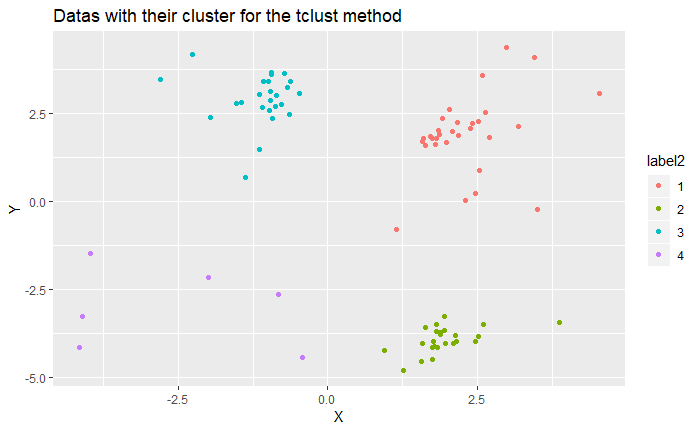

```r
clusterCut<- as.character(clusterCut)
dfCluster = data.frame("X" = c(x1,x2,x3,xUniform), "Y" = c(y1,y2,y3,yUniform),"label2" = clusterCut)
ggplot(dfCluster, aes(x = X, y = Y,color = label2)) + geom_point() + ggtitle("Datas with their cluster for the tclust method")
```

```r
emobj <- simple.init(df[, 1:2], nclass = 4)
emobj <- shortemcluster(df[, 1:2], emobj)
summary(emobj)
```

```
Method:
 n = 85, p = 2, nclass = 4, flag = , total parameters = 23,
 conv.iter = 11, conv.eps = 0.009042238,
 logL = -291.2907, AIC = 628.5815, BIC = 684.7624.
nc:
[1] 4
pi:
[1] 0.08082 0.62509 0.10409 0.19000
```

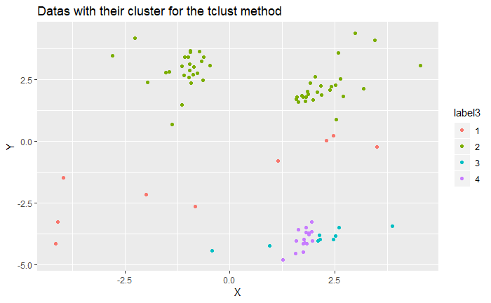

```r
ret <- emcluster(df[, 1:2], emobj, assign.class = TRUE)
clusterPredict <- ret$class
clusterPredict<- as.character(clusterPredict)
dfCluster = data.frame("X" = c(x1,x2,x3,xUniform), "Y" = c(y1,y2,y3,yUniform),"label3" = clusterPredict)
ggplot(dfCluster, aes(x = X, y = Y,color = label3)) + geom_point() + ggtitle("Datas with their cluster for the tclust method")
```

The second algorithm has bad results. He is not able to distinguish two clusters which are cleary separated. Whereas the robust algorithm has issues only on the points generates uniformally.